Skip to main content

# Case 31 – Employees Federal Credit Union

Reliability and Factor Analysis for the R3 and R6 Scales

Author

Cecilia Espina

Published

November 16, 2026

# Overview

This report checks whether the two multi-item scales in Case 31 are **valid** (factor analysis) and **reliable** (Cronbach’s α), and what that means for the next step: whether to combine the items into a **composite scale**. It does not address the research questions themselves (that comes later).

| Scale | Research question | Items |
| --- | --- | --- |
| Attitude toward employee proficiency | R3 | Q3–Q6 |
| Attitude toward operational effectiveness | R6 | Q31–Q34 |

**Decision rules used** (common benchmarks)

| Check | Question it answers | Benchmark |
| --- | --- | --- |
| Kaiser–Meyer–Olkin (KMO) | Are the items correlated enough to factor? | ≥ .60 preferred (.50 minimum) |
| Bartlett’s test of sphericity | Is the correlation matrix different from “no correlations”? | *p* < .05 |
| Number of factors (Kaiser criterion, scree plot) | Do the items form one dimension? **One** factor is expected for one construct | Only one eigenvalue > 1 |
| Loadings and communalities | Does each item measure the factor (convergent validity)? | Loading ≥ .50; communality ≥ .50 |
| Cronbach’s α | Are the items internally consistent (reliability)? | α ≥ .70 |
| Corrected item–total correlation | Does each item fit with the rest? | ≥ .30 |

Factor analysis uses principal components extraction, and components are rotated (varimax) only when more than one has an eigenvalue above 1. Only if a scale shows both validity and reliability is a composite (the mean of its items) justified.

# R3 · Attitude toward employee proficiency

## R3 · Descriptive statistics and correlations

The attitude toward employee proficiency scale has four items (Q3 courteous, Q4 helpful, Q5 professional, Q6 always available), each rated from 1 (strongly disagree) to 5 (strongly agree) by 128 members (Table 1). Factor analysis starts from the correlations among the items (Table 2), which range from 0.46 to 0.72.

Table 1: Attitude toward employee proficiency: item descriptive statistics

| Item | n | Mean | SD | Min | Max |
| --- | --- | --- | --- | --- | --- |
| Q3 Courteous | 128 | 4.35 | 0.66 | 3 | 5 |
| Q4 Helpful | 128 | 4.31 | 0.70 | 2 | 5 |
| Q5 Professional | 128 | 4.08 | 0.66 | 3 | 5 |
| Q6 Always available | 128 | 4.08 | 0.79 | 2 | 5 |

Table 2: Correlations among the items (Pearson r)

|  | Item | Q3 | Q4 | Q5 | Q6 |
| --- | --- | --- | --- | --- | --- |
| q3 | Q3 Courteous | 1.00 |  |  |  |
| q4 | Q4 Helpful | 0.72 | 1.00 |  |  |
| q5 | Q5 Professional | 0.57 | 0.68 | 1.00 |  |
| q6 | Q6 Always available | 0.46 | 0.67 | 0.64 | 1.00 |

## R3 · Factor analysis

**Is the data suitable?** Yes. The KMO measure is 0.78, above the .60 benchmark, and Bartlett’s test is significant (χ²(6) = 263.61, *p* < .001), so the items share enough variance to be factored (Table 3).

Table 3: R3: KMO measure of sampling adequacy (MSA) and Bartlett’s test

| Measure | Value |
| --- | --- |
| KMO (overall) | 0.78 |
| MSA: Q3 | 0.76 |
| MSA: Q4 | 0.73 |
| MSA: Q5 | 0.84 |
| MSA: Q6 | 0.79 |
| Bartlett’s χ² | 263.61 |
| df | 6 |
| p | < .001 |

**How many factors?** Only 1 component has an eigenvalue above 1. The first has an eigenvalue of 2.88 (explaining 72% of the variance) and the next is only 0.55 (Table 4). The scree plot shows a sharp drop after the first component (Figure 1). This is the **single factor** we expect from one construct.

Table 4: R3: eigenvalues and variance explained

| Component | Eigenvalue | % of variance | Cumulative % |
| --- | --- | --- | --- |
| 1 | 2.88 | 72.0% | 72.0% |
| 2 | 0.55 | 13.9% | 85.9% |
| 3 | 0.35 | 8.7% | 94.6% |
| 4 | 0.22 | 5.4% | 100.0% |

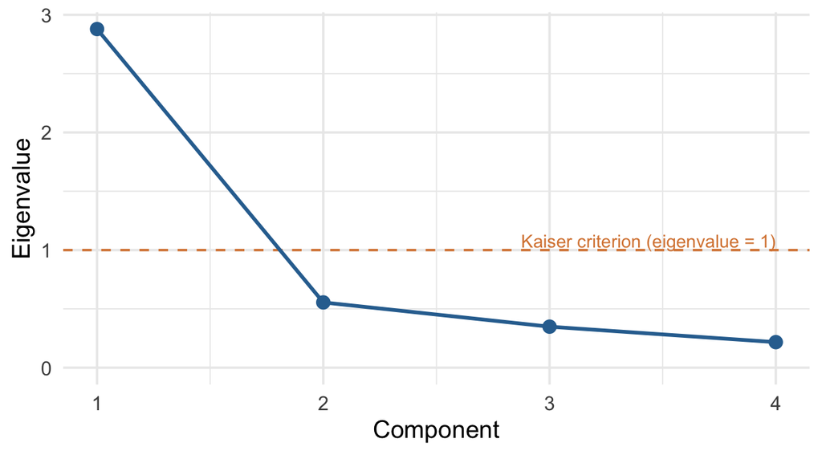

Figure 1: R3: scree plot

**Do the items measure that factor?** Yes. All loadings are high (0.81–0.91) and all communalities (0.65–0.83) are above .50, so each item shares most of its variance with the common factor (Table 5). This supports **convergent validity**.

Table 5: R3: loadings and communalities (one-component solution)

| Item | Loading | Communality (h²) | Uniqueness |
| --- | --- | --- | --- |
| Q3 Courteous | 0.81 | 0.65 | 0.35 |
| Q4 Helpful | 0.91 | 0.83 | 0.17 |
| Q5 Professional | 0.85 | 0.73 | 0.27 |
| Q6 Always available | 0.81 | 0.66 | 0.34 |

## R3 · Reliability analysis

Cronbach’s α is **0.87**, above the .70 benchmark, with an average inter-item correlation of 0.62. Every item correlates well with the rest of the scale (corrected item–total *r* of 0.66–0.82, all above .30), and deleting any item would not raise α (the highest α-if-deleted is 0.85) (Table 6).

Table 6: R3: reliability analysis (Cronbach’s α)

| Item | Corrected item–total r | α if item deleted |
| --- | --- | --- |
| Q3 Courteous | 0.66 | 0.85 |
| Q4 Helpful | 0.82 | 0.79 |
| Q5 Professional | 0.73 | 0.82 |
| Q6 Always available | 0.67 | 0.85 |
| **Scale (all items)** | α = 0.87 | avg. r = 0.62 |

## R3 · Conclusion and next step

The scale shows **one clear factor**, strong communalities and **high reliability** (α = 0.87). **Decision: create a composite.** In the later analysis for R3, use the **mean of Q3–Q6** as the employee proficiency index instead of analyzing the four items separately.

# R6 · Attitude toward operational effectiveness

## R6 · Descriptive statistics and correlations

The attitude toward operational effectiveness scale has four items (Q31 keeps information confidential, Q32 prompt loan processing, Q33 services meet needs, Q34 simple applications), each rated from 1 (strongly disagree) to 5 (strongly agree) by 128 members (Table 7). Factor analysis starts from the correlations among the items (Table 8), which range from 0.00 to 0.39.

Table 7: Attitude toward operational effectiveness: item descriptive statistics

| Item | n | Mean | SD | Min | Max |
| --- | --- | --- | --- | --- | --- |
| Q31 Keeps information confidential | 128 | 3.95 | 0.68 | 1 | 5 |
| Q32 Prompt in processing loan applications | 128 | 3.72 | 0.79 | 2 | 5 |
| Q33 Services meet members’ needs | 128 | 3.59 | 0.68 | 2 | 5 |
| Q34 Loan applications simple and easy | 128 | 3.46 | 0.78 | 1 | 5 |

Table 8: Correlations among the items (Pearson r)

|  | Item | Q31 | Q32 | Q33 | Q34 |
| --- | --- | --- | --- | --- | --- |
| q31 | Q31 Keeps information confidential | 1.00 |  |  |  |
| q32 | Q32 Prompt in processing loan applications | 0.28 | 1.00 |  |  |
| q33 | Q33 Services meet members’ needs | 0.12 | 0.22 | 1.00 |  |
| q34 | Q34 Loan applications simple and easy | 0.00 | 0.39 | 0.04 | 1.00 |

## R6 · Factor analysis

**Is the data suitable?** Only marginally. Bartlett’s test is significant (χ²(6) = 39.33, *p* < .001), so some correlation exists, but the correlations are small and the KMO measure is 0.50, right at the lowest acceptable value (.50), with several item-level values at or below it (Table 9). The items share little common variance.

Table 9: R6: KMO measure of sampling adequacy (MSA) and Bartlett’s test

| Measure | Value |
| --- | --- |
| KMO (overall) | 0.50 |
| MSA: Q31 | 0.49 |
| MSA: Q32 | 0.50 |
| MSA: Q33 | 0.60 |
| MSA: Q34 | 0.46 |
| Bartlett’s χ² | 39.33 |
| df | 6 |
| p | < .001 |

**How many factors?** Not one. 2 components have eigenvalues above 1 (1.58 and 1.03), and the first explains only 39% of the variance (Table 10 and Figure 2). We expect a single factor for one construct, so the items do **not** form one dimension.

Table 10: R6: eigenvalues and variance explained

| Component | Eigenvalue | % of variance | Cumulative % |
| --- | --- | --- | --- |
| 1 | 1.58 | 39.4% | 39.4% |
| 2 | 1.03 | 25.8% | 65.3% |
| 3 | 0.88 | 22.0% | 87.3% |
| 4 | 0.51 | 12.7% | 100.0% |

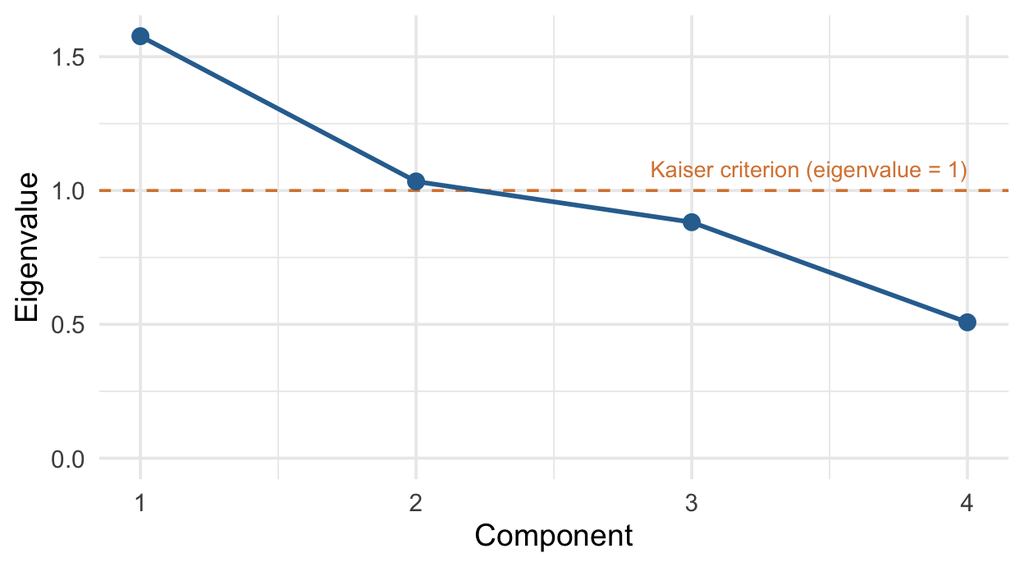

Figure 2: R6: scree plot

**Do the items measure one factor?** No. If forced into one component, the loadings are 0.48–0.84 and the communalities 0.23–0.71; only one item reaches .50 (Table 11). The rotated two-component solution splits the items: Q32 (prompt processing) and Q34 (simple applications) group together, while Q31 (confidentiality) and Q33 (meets needs) group together, with Q32 also cross-loading on the other component (Table 12; loadings of .40 or more in bold). The items therefore do not show **convergent validity** as one scale.

Table 11: R6: loadings and communalities (one-component solution)

| Item | Loading | Communality (h²) | Uniqueness |
| --- | --- | --- | --- |
| Q31 Keeps information confidential | 0.51 | 0.26 | 0.74 |
| Q32 Prompt in processing loan applications | 0.84 | 0.71 | 0.29 |
| Q33 Services meet members’ needs | 0.48 | 0.23 | 0.77 |
| Q34 Loan applications simple and easy | 0.61 | 0.37 | 0.63 |

Table 12: R6: rotated components (varimax; Kaiser criterion)

| Item | Component 1 | Component 2 | Communality |
| --- | --- | --- | --- |
| Q31 Keeps information confidential | 0.01 | **0.78** | 0.61 |
| Q32 Prompt in processing loan applications | **0.72** | **0.46** | 0.73 |
| Q33 Services meet members’ needs | 0.08 | **0.65** | 0.43 |
| Q34 Loan applications simple and easy | **0.91** | -0.13 | 0.84 |

## R6 · Reliability analysis

Cronbach’s α is only **0.47**, well below the .70 benchmark, and the average inter-item correlation is 0.18. The corrected item–total correlations (0.19–0.49) are below .30 for most items, and no deletion helps (the highest α-if-deleted is 0.47) (Table 13). The items are **not internally consistent**.

Table 13: R6: reliability analysis (Cronbach’s α)

| Item | Corrected item–total r | α if item deleted |
| --- | --- | --- |
| Q31 Keeps information confidential | 0.19 | 0.47 |
| Q32 Prompt in processing loan applications | 0.49 | 0.14 |
| Q33 Services meet members’ needs | 0.19 | 0.47 |
| Q34 Loan applications simple and easy | 0.23 | 0.44 |
| **Scale (all items)** | α = 0.47 | avg. r = 0.18 |

## R6 · Conclusion and next step

Q31–Q34 do **not** form one factor and are **not reliable** as a sum (α = 0.47). **Decision: do not create a composite.** In the later analysis for R6, analyze **each of Q31, Q32, Q33 and Q34 as its own variable.**

# Discriminant validity: both scales together

Discriminant validity asks whether the items load on the construct they are meant to represent and not on the other one. With all eight items together, Bartlett’s test is significant (χ²(28) = 360.10, *p* < .001) and the KMO measure is 0.80. 2 components have eigenvalues above 1 (3.46 and 1.27) (Table 14).

Table 14: Both scales together: rotated components (varimax; loadings of .40 or more in bold)

| Item | Component 1 | Component 2 | Communality |
| --- | --- | --- | --- |
| Q3 Courteous | **0.78** | -0.09 | 0.62 |
| Q4 Helpful | **0.88** | 0.11 | 0.79 |
| Q5 Professional | **0.85** | 0.05 | 0.72 |
| Q6 Always available | **0.80** | 0.19 | 0.68 |
| Q31 Keeps information confidential | 0.37 | 0.19 | 0.17 |
| Q32 Prompt in processing loan applications | 0.38 | **0.75** | 0.71 |
| Q33 Services meet members’ needs | **0.51** | 0.13 | 0.27 |
| Q34 Loan applications simple and easy | -0.09 | **0.86** | 0.75 |

# Summary and decision

| Scale | Factors (eigenvalue > 1) | KMO | One-component communalities | Cronbach’s α | **Decision** |
| --- | --- | --- | --- | --- | --- |
| R3 Employee proficiency (Q3–Q6) | 1 | 0.78 | 0.65–0.83 | 0.87 | **Create a composite** (mean of Q3–Q6) |
| R6 Operational effectiveness (Q31–Q34) | 2 | 0.50 | 0.23–0.71 | 0.47 | **No composite**; analyze Q31–Q34 individually |

# Appendix

**Links**

- GitHub repository: https://github.com/espinacecilia-design/6500/tree/main/IC10-case31
- GitHub Pages (published report): https://espinacecilia-design.github.io/6500/IC10-case31/IC_Case31_Reliability-FactorAnalysis_Cecilia_Espina.html

**Notes on method**

- Data: cleaned SPSS file, N = 128 (no missing values on these eight items).
- Packages: `psych` (`KMO()`, `cortest.bartlett()`, `principal()`, `alpha()`). Install once with `install.packages("psych")`.
- Extraction: principal components. Components with eigenvalues above 1 are kept (Kaiser criterion) and rotated with varimax when there is more than one.
- Reliability: raw Cronbach’s α, corrected item–total correlations (`r.drop`) and α if item deleted.